# Lab 7: RNA-Seq workflow: gene-level exploratory analysis and differential expression

# tximeta created object gse with three matrics: counts - the estimated fragments counts for each gene and sample; abundance - estimated trancipts abundances; length - the effective gene lengths which include changes in length due to biases as well as transcript usage

# can investigate SummarizedExperiment object by looking at the matrices in assays slot, the phenotypic data in colData, and the data about genes in rowRanges

```r
# load the full count matric corresponding to all samples and all data, which is provided in airway package, and will continue the analysis with full data object
data(gse)
gse
```

```
## class: RangedSummarizedExperiment
## dim: 58294 8
## metadata(6): tximetaInfo quantInfo ... txomeInfo txdbInfo
## assays(3): counts abundance length
## rownames(58294): ENSG00000000003.14 ENSG00000000005.5 ...
##   ENSG00000285993.1 ENSG00000285994.1
## rowData names(1): gene_id
## colnames(8): SRR1039508 SRR1039509 ... SRR1039520 SRR1039521
## colData names(3): names donor condition
```

```r
## counts are the first matrix and can examine them with assay
assayNames(gse)
```

```
## [1] "counts"    "abundance" "length"
```

```r
head(assay(gse), 3)
```

```
##                    SRR1039508 SRR1039509 SRR1039512 SRR1039513 SRR1039516
## ENSG00000000003.14    708.164    467.962    900.992    424.368   1188.295
## ENSG00000000005.5       0.000      0.000      0.000      0.000      0.000
## ENSG00000000419.12    455.000    510.000    604.000    352.000    583.000
##                    SRR1039517 SRR1039520 SRR1039521
## ENSG00000000003.14   1090.668    805.929    599.337
## ENSG00000000005.5       0.000      0.000      0.000
## ENSG00000000419.12    773.999    409.999    499.000
```

```r
colSums(assay(gse))
```

```
## SRR1039508 SRR1039509 SRR1039512 SRR1039513 SRR1039516 SRR1039517 SRR1039520
##   21100805   19298584   26145537   15688246   25268618   31891456   19683767
## SRR1039521
##   21813903
```

```r
## when printed, shows ranges for the first five and last five genes
rowRanges(gse)
```

```
## GRanges object with 58294 ranges and 1 metadata column:
##                      seqnames              ranges strand |            gene_id
##                         <Rle>           <IRanges>  <Rle> |        <character>
##   ENSG00000000003.14     chrX 100627109-100639991      - | ENSG00000000003.14
##    ENSG00000000005.5     chrX 100584802-100599885      + |  ENSG00000000005.5
##   ENSG00000000419.12    chr20   50934867-50958555      - | ENSG00000000419.12
##   ENSG00000000457.13     chr1 169849631-169894267      - | ENSG00000000457.13
##   ENSG00000000460.16     chr1 169662007-169854080      + | ENSG00000000460.16
##                  ...      ...                 ...    ... .                ...
##    ENSG00000285990.1    chr14   19244904-19269380      - |  ENSG00000285990.1
##    ENSG00000285991.1     chr6 149817937-149896011      - |  ENSG00000285991.1
##    ENSG00000285992.1     chr8   47129262-47132628      + |  ENSG00000285992.1
##    ENSG00000285993.1    chr18   46409197-46410645      - |  ENSG00000285993.1
##    ENSG00000285994.1    chr10   12563151-12567351      + |  ENSG00000285994.1
##   -------
##   seqinfo: 25 sequences (1 circular) from hg38 genome
```

```r
## rowRanges contains metadata about sequences, chromosomes in this case, in the seqinfo slot
seqinfo(rowRanges(gse))
```

```
## Seqinfo object with 25 sequences (1 circular) from hg38 genome:
##   seqnames seqlengths isCircular genome
##   chr1      248956422      FALSE   hg38
##   chr2      242193529      FALSE   hg38
##   chr3      198295559      FALSE   hg38
##   chr4      190214555      FALSE   hg38
##   chr5      181538259      FALSE   hg38
##   ...             ...        ...    ...
##   chr21      46709983      FALSE   hg38
##   chr22      50818468      FALSE   hg38
##   chrX      156040895      FALSE   hg38
##   chrY       57227415      FALSE   hg38
##   chrM          16569       TRUE   hg38
```

```r
## colData reflects the data.fram that was provided by tximeta function for importing quantification data; can see that there are columns indicating sample names, as well as the donor ID, and the treatment condition
colData(gse)
```

```
## DataFrame with 8 rows and 3 columns
##                 names    donor     condition
##              <factor> <factor>      <factor>
## SRR1039508 SRR1039508  N61311  Untreated
## SRR1039509 SRR1039509  N61311  Dexamethasone
## SRR1039512 SRR1039512  N052611 Untreated
## SRR1039513 SRR1039513  N052611 Dexamethasone
## SRR1039516 SRR1039516  N080611 Untreated
## SRR1039517 SRR1039517  N080611 Dexamethasone
## SRR1039520 SRR1039520  N061011 Untreated
## SRR1039521 SRR1039521  N061011 Dexamethasone
```

## 2.6 Branching Point

# the previous information allowed us to start our analysis

## 3. The DESeqDataSet object, sample information and design formula

```r
# DESeq2, a custom class is DESeqDataSet, and it is easy to convert SummarizedExperiment class from Bioconductor to DESeqDataSet; assay slot is instead accessed using counts accesors function and DESeqDataSet class enforces that the values in this matrix are non-negative integers; DESeqDataSet has an associated design formula: experimental desgin is specified at beginning of the analysis as it will inform many of the DESeq2 function how to treat the samples in the anaylsis (expection is the size factor estimation)

# design formula tells which columns in the sample info table (colData) specify the experimental design and how these factors should be used in this analysis
```

```r
# examine columns of colData of gse; can see each of columns using $ directly on the SummarizedExperiment or DESeqDataSet

gse$donor
```

```
## [1] N61311  N61311  N052611 N052611 N080611 N080611 N061011 N061011
## Levels: N052611 N061011 N080611 N61311
```

```r
gse$condition
```

```
## [1] Untreated     Dexamethasone Untreated     Dexamethasone Untreated
## [6] Dexamethasone Untreated     Dexamethasone
## Levels: Untreated Dexamethasone
```

```r
# rename variables using cell to denote cell line and dex to denote treatment condition
gse$cell <- gse$donor
gse$dex <- gse$condition
```

```r
# change names of levels; it is important to rename levels to not change the order: untreated will be untrt nd dexamethasone as trt
levels(gse$dex)
```

```
## [1] "Untreated"     "Dexamethasone"
```

```r
# when renaming levels, the order must be preserved
levels(gse$dex) <- c("untrt", "trt")
```

```r
# the simplest design formula for differential expression would be ~ condition, where condition is a column in colData(dds) that specifices which of two or more groups the sampes belong to; can sepcify ~ cell + dex meaning that we want to test for the effect of dex and effect of different cell line

# it is prefered in R that the first level of a factor be the reference level; when colData was assembled, the untreateed samples were already set as the reference, but if this were not the case, we could use relevel, which decides how the variables will be coded and how contrasts will be computed; for a two-group comparison, the use of relevel to change the reference level would flip the sign of a coefficient associated with a contrast between two groups
```

```r
library("magrittr")
gse$dex %<>% relevel("untrt")
gse$dex
```

```
## [1] untrt trt   untrt trt   untrt trt   untrt trt
## Levels: untrt trt
```

# %<>% is a compound assignment pipe-operater that allow concise expression

```r
gse$dex <- relevel(gse$dex, "untrt")
```

## 3.1 Starting from SummarizedExperiment

```r
round(colSums(assay(gse))/ 1e6, 1)
```

```
## SRR1039508 SRR1039509 SRR1039512 SRR1039513 SRR1039516 SRR1039517 SRR1039520
##       21.1       19.3       26.1       15.7       25.3       31.9       19.7
## SRR1039521
##       21.8
```

```r
# since SummarizedExperiment fully annotated, can construct a DESeqDataSet object from it that will then form the startin point of the anaylsis

library("DESeq2")

dds <- DESeqDataSet(gse, design = ~ cell +dex)
```

## 3.2 Starting from count matrices

```r
# build an DESeqDataSet with a count matri and table of sample info
```

```r
# use assay function to see the fragments counts of the actual data and use head function to restrict output to first few line

countdata <- round(assays(gse)[["counts"]])
head(countdata, 3)
```

```
##                    SRR1039508 SRR1039509 SRR1039512 SRR1039513 SRR1039516
## ENSG00000000003.14        708        468        901        424       1188
## ENSG00000000005.5           0          0          0          0          0
## ENSG00000000419.12        455        510        604        352        583
##                    SRR1039517 SRR1039520 SRR1039521
## ENSG00000000003.14       1091        806        599
## ENSG00000000005.5           0          0          0
## ENSG00000000419.12        774        410        499
```

```r
# in count matrix, each row represents a gene, each column a sequenced RNA library, and values give the estimated counts of fragments that were probabilistically assigned to the respective gene in each library
# if the count data is imported, it is extremely important to check manually that the columns of the count matrix correspond to the rows of the sample info table
coldata <- colData(gse)

# to prepare data object in a form that is suitable for analysis:
# countdata: a table with the fragment counts
# coldata: a table with info about the samples

# to construct the DESeqDataSet object from matrix of counts and the sample info table, use
ddsMat <- DESeqDataSetFromMatrix(countData = countdata,
                                 colData = coldata,
                                 design = ~ cell +dex)
```

## 4. Exploratory analysis and visualization

```r
# first transformations of counts in order to visualize explore sample relationships; go back to the original raw counts for statistical testing; this is critical because the statistical testing methods rely on original count data for calculating the precision of measurements
```

## 4.1 Pre-filtering the dataset

```r
# matrix with DESeqDataSet contains many rows with only zeros, and additionally many rows with only a few fragments total; to reduce size of object and to increase the speed of our functions, remove the rows that have no or nearly no information about the amount of gene expression; apply most minimal filtering rule: removing rows of the DESeqDataSet that have no counts, or only a single count across all sample; weighting/filtering to improve power is applied at a later step in the workflow
```

```r
nrow(dds)
```

```
## [1] 58294
```

```r
keep <- rowSums(counts(dds)) > 1
dds <- dds[keep,]
nrow(dds)
```

```
## [1] 31604
```

```r
# perform additional filtering; one can specify at least 3 samples have a count of 10 or higher: for the number of sample would be set to the smallest group size, could be specified by creating a logic vector and subsetting dds

# at least 3 samples with a count of 10 or higher
keep <- rowSums(counts(dds) >= 10) >= 3
```

## 4.2 The variance stabilizing transformation and the rlog

```r
# clustering and principal components analysis (PCA) work best for data that generally has the same range of variance at different ranges of the mean values; when expected variance is approximately the same across different mean values, the data is said to be homoskedastic
# for RNA-seq counts, the expected variance grows with the mean; if one performs PCA directly on a matrix of counts or normalized counts, the resulting plot typically depends monstly on the genes with highest counts becuase they show the largest absolute differences between samples - to avoid, take the log of the noramlzied count values plus a pseudocount of 1; depending on the choice of pseudocount, now the genes with the very lowest counts will contribute a great deal of noise to the resulting plot because taking the log of small counts actually inflants their variance
# can show property of counts with some simulated data (here, Poisson counts with a range of lambda from 0.1 to 100); plot standard deviation of each row (genes) against the mean
```

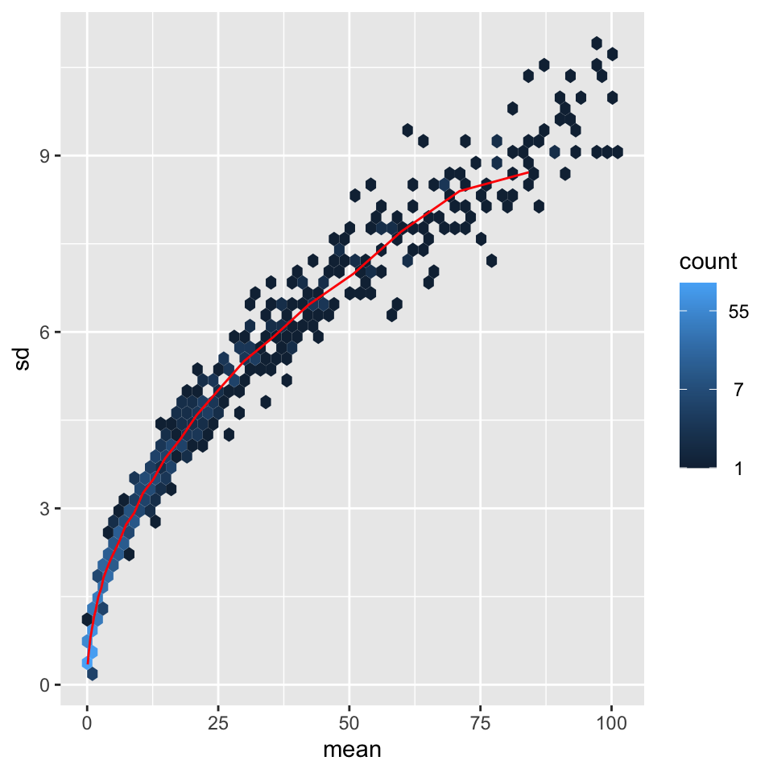

```r
# plot of mean by SD plot
lambda <- 10^seq(from = -1, to = 2, length = 1000)
cts <- matrix(rpois(1000*100, lambda), ncol = 100)
library("vsn")
meanSdPlot(cts, ranks = FALSE)
```

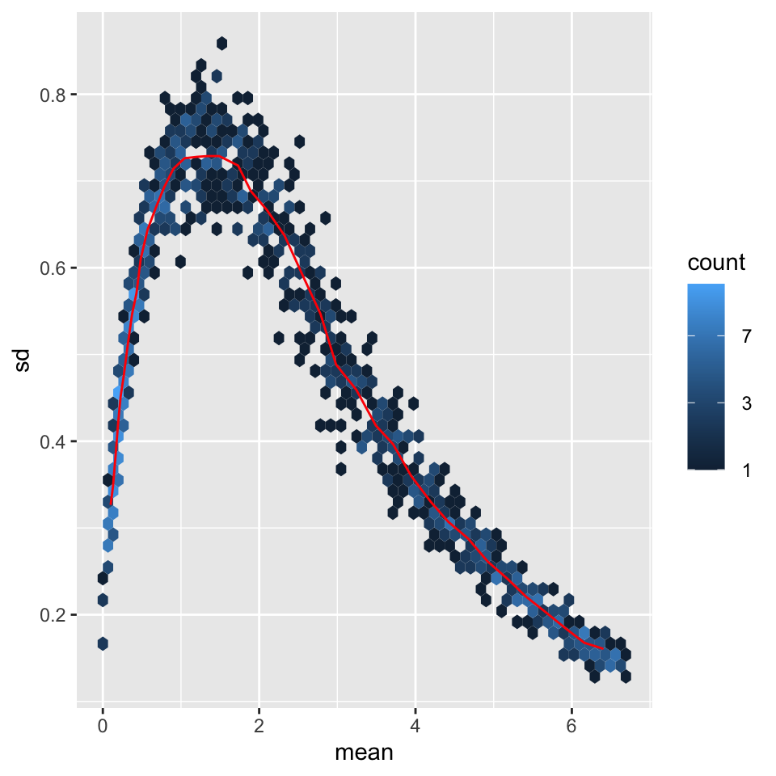

```r
# log-transformed counts
log.cts.one <- log2(cts +1)
meanSdPlot(log.cts.one, ranks = FALSE)
```

```r
# the log with a small pseudocount amplifies differences when the values are close to 0; low count genes with low signal-to-noise ratio with overly contribute to sample-sample distances and PCA plots

# to count data that stabilize the variance across the mean: the variance stabilizing transformation (VST) for negative binomial data with a dispersion-mean trend, implemented in the vst function, and the regularlized-logarithm or rlog

# for genes with high g=counts, both VST and rlog will give similar results to the ordinary log2 transformation of normalized counts; for lower count genes, the values are shrunken to the middle value; the vst or rlog-transformed data then become approximately homoskedastic (more flat trend in the meanSdPlot) and can be used directly for computing distances between samples, making PCS plots, or as input to downstream methods which perform best with homoskedastic data

## What transformation to choose?

# the vst is much faster to compute and is les sensitive to high count outliers than rlog; rlog tends to work well on small datasets (n <30), potentially outperforming the vst when there is a wide range of sequencing depth across samples

# use vst for medium-to-large datasets where n >30; use rlog when samples are less than 30

# can compare both transformations by using meanSdPlot or PCA plots
```

```r
# using VSD to create a dataset for comparison
vsd <- vst(dds, blind = FALSE)
head(assay(vsd), 3)
```

```
##                    SRR1039508 SRR1039509 SRR1039512 SRR1039513 SRR1039516
## ENSG00000000003.14  10.105781   9.852029  10.169726   9.991545  10.424865
## ENSG00000000419.12   9.692244   9.923647   9.801921   9.798653   9.763455
## ENSG00000000457.13   9.449592   9.312186   9.362754   9.459168   9.281415
##                    SRR1039517 SRR1039520 SRR1039521
## ENSG00000000003.14  10.194490  10.315814  10.002177
## ENSG00000000419.12   9.874703   9.683211   9.845507
## ENSG00000000457.13   9.395937   9.477971   9.477027
```

```r
colData(vsd)
```

```
## DataFrame with 8 rows and 5 columns
##                 names    donor     condition     cell      dex
##              <factor> <factor>      <factor> <factor> <factor>
## SRR1039508 SRR1039508  N61311  Untreated      N61311     untrt
## SRR1039509 SRR1039509  N61311  Dexamethasone  N61311     trt
## SRR1039512 SRR1039512  N052611 Untreated      N052611    untrt
## SRR1039513 SRR1039513  N052611 Dexamethasone  N052611    trt
## SRR1039516 SRR1039516  N080611 Untreated      N080611    untrt
## SRR1039517 SRR1039517  N080611 Dexamethasone  N080611    trt
## SRR1039520 SRR1039520  N061011 Untreated      N061011    untrt
## SRR1039521 SRR1039521  N061011 Dexamethasone  N061011    trt
```

```r
# using rlog to create a dataset for comparison
rld <- rlog(dds, blind = FALSE)
head(assay(rld), 3)
```

```
##                    SRR1039508 SRR1039509 SRR1039512 SRR1039513 SRR1039516
## ENSG00000000003.14   9.482613   9.172197   9.558383   9.346001   9.851349
## ENSG00000000419.12   8.860186   9.150196   9.000042   8.995902   8.951327
## ENSG00000000457.13   8.354790   8.166700   8.236582   8.366693   8.121781
##                    SRR1039517 SRR1039520 SRR1039521
## ENSG00000000003.14   9.587602   9.727248   9.357876
## ENSG00000000419.12   9.091075   8.848782   9.054384
## ENSG00000000457.13   8.282307   8.392384   8.391023
```

```r
# use blind = FALSE, which means that differences between cell lines and treatment (the variables in the design) will not contribute to the expected variance-mean trend of the experiment; experimental design is used to estimate the global amount of variability in counts; for fully unsupervised transformation, one can set blind = TRUE

# to show effects of transformation, plot the first sample against the second; using log2 function first (and adding 1 to avoid taking log of 0) and then using VST and rlog transformed values

# for log2 approach, we need to first estimate size factors to account for sequencing depth, then specify normalized = TRUE; sequencing depth correction is done automatically for the vst and rlog
```

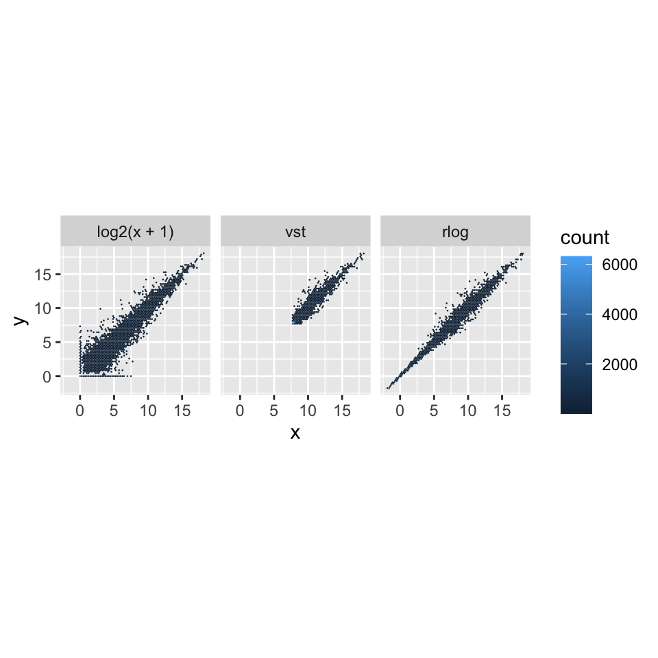

```r
# comparing graphs to see variance

library("dplyr")
library("ggplot2")

dds <- estimateSizeFactors(dds)

df <- bind_rows(
  as_data_frame(log2(counts(dds, normalized=TRUE)[, 1:2]+1)) %>%
         mutate(transformation = "log2(x + 1)"),
  as_data_frame(assay(vsd)[, 1:2]) %>% mutate(transformation = "vst"),
  as_data_frame(assay(rld)[, 1:2]) %>% mutate(transformation = "rlog"))

colnames(df)[1:2] <- c("x", "y")

lvls <- c("log2(x + 1)", "vst", "rlog")
df$transformation <- factor(df$transformation, levels=lvls)

ggplot(df, aes(x = x, y = y)) + geom_hex(bins = 80) +
  coord_fixed() + facet_grid( . ~ transformation)
```

## 4.3 Sample Distances

```r
# first step in an RNA-seq analysis is often to assess overall similarity between: which samples are similar to each other, which are different? Does this fit to the expectation from the experiment's design?

# use R function dist to calculate the Euclidean distance between samples; to have roughly equal contribution from all genes, we use it on VST data; need to transpose the matrix of values using t, because the dist function expects the different samples to be rows of its argument, and different dimensions (here, genes) to be columns
```

```r
sampleDists <- dist(t(assay(vsd)))
sampleDists
```

```
##            SRR1039508 SRR1039509 SRR1039512 SRR1039513 SRR1039516 SRR1039517
## SRR1039509   39.42362
## SRR1039512   32.37620   44.93748
## SRR1039513   51.09677   37.18799   41.79886
## SRR1039516   35.59642   47.54671   34.83458   52.05265
## SRR1039517   51.26314   41.58572   46.89609   40.67315   39.74268
## SRR1039520   32.38578   46.96000   30.35980   48.08669   37.07106   50.38349
## SRR1039521   51.49108   37.57383   47.17283   31.45899   52.62276   41.35941
##            SRR1039520
## SRR1039509
## SRR1039512
## SRR1039513
## SRR1039516
## SRR1039517
## SRR1039520
## SRR1039521   43.01502
```

```r
## to visualize heatmap, using function pheatmap
library("pheatmap")
library("RColorBrewer")
```

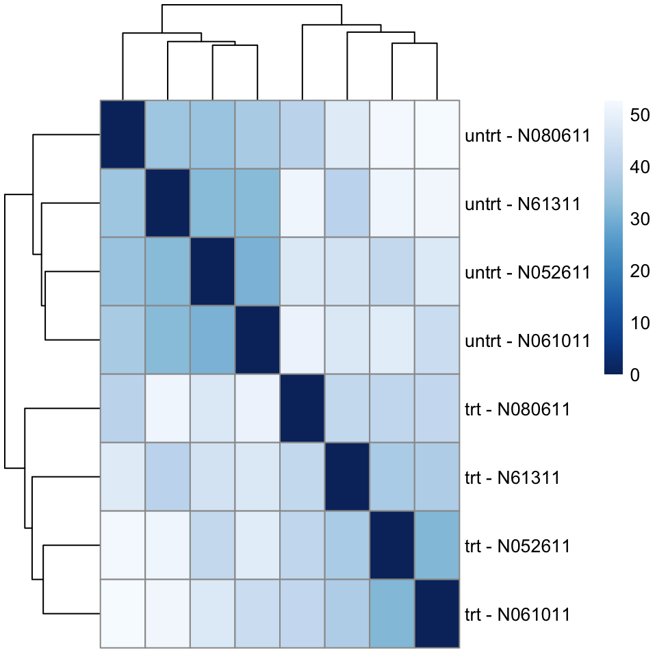

```r
# in order to plot sample distance matrix with rows/columns arranged by distance in distance matrix, manually provide sampledists to clustering_distance argument of pheatmap (otherwise, it would assume that the matrix contains the data values themselves, and would calculate distances between rows/columns of the distance matrix, which is not desired)
# use blue color palette using colorRampPalette function from RColorBrewer package

sampleDistMatrix <- as.matrix( sampleDists )
rownames(sampleDistMatrix) <- paste( vsd$dex, vsd$cell, sep = " - " )
colnames(sampleDistMatrix) <- NULL
colors <- colorRampPalette( rev(brewer.pal(9, "Blues")) )(255)
pheatmap(sampleDistMatrix,
         clustering_distance_rows = sampleDists,
         clustering_distance_cols = sampleDists,
         col = colors)
```

```r
# Heatmap of sample-to-sample distances using the variance stabilizing transformed values

# changed row names of distance matrix to contain treatment type and patient number instead of sample ID, so that we have all this info in view when looking at heatmap

# another way to calculate sample distances is to use poisson distance, implemented in PoiClaClu package: measure of dissimilarity between count also takes the inherent variance structure of counts into consideration when calculating the distances between samples
```

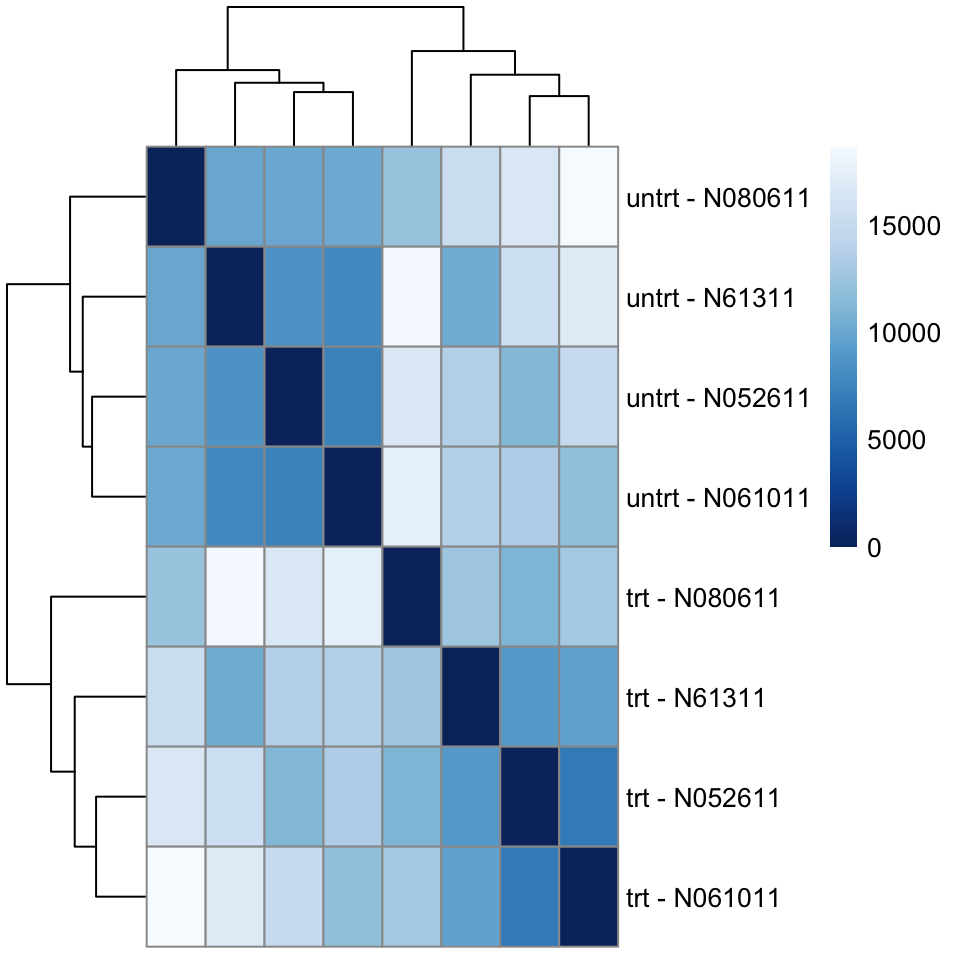

```r
# PoissonDistance fnction takes the original count matrix (not normalized) with sample as rows instead of columns, so must transpose counts using dds

library("PoiClaClu")
poisd <- PoissonDistance(t(counts(dds)))

# plotting heatmap

samplePoisDistMatrix <- as.matrix( poisd$dd )
rownames(samplePoisDistMatrix) <- paste( dds$dex, dds$cell, sep=" - " )
colnames(samplePoisDistMatrix) <- NULL
pheatmap(samplePoisDistMatrix,
         clustering_distance_rows = poisd$dd,
         clustering_distance_cols = poisd$dd,
         col = colors)
```

```r
# heatmap of sample-to-sample distances using Poisson Distance

## 4.4 PCA Plot
# PCA, or principal components analysis: a way to visualize sample-to-sample distances; data points are projected onto 2D plane such that they spread out in two directions that explain most of thei differences

# x-axis is the direction that separates the data points the most: the values of the samples in this direction are written PC1

# y-axis is a direction (must be orthogonal) that seaparates the data the second most; values of the samples in this direction are written PC2

# the percent of total variance that is contained in the direction is printed in the axis label (percentages do not add to 100% because there are more dimensions that contain the remaining variance)
```

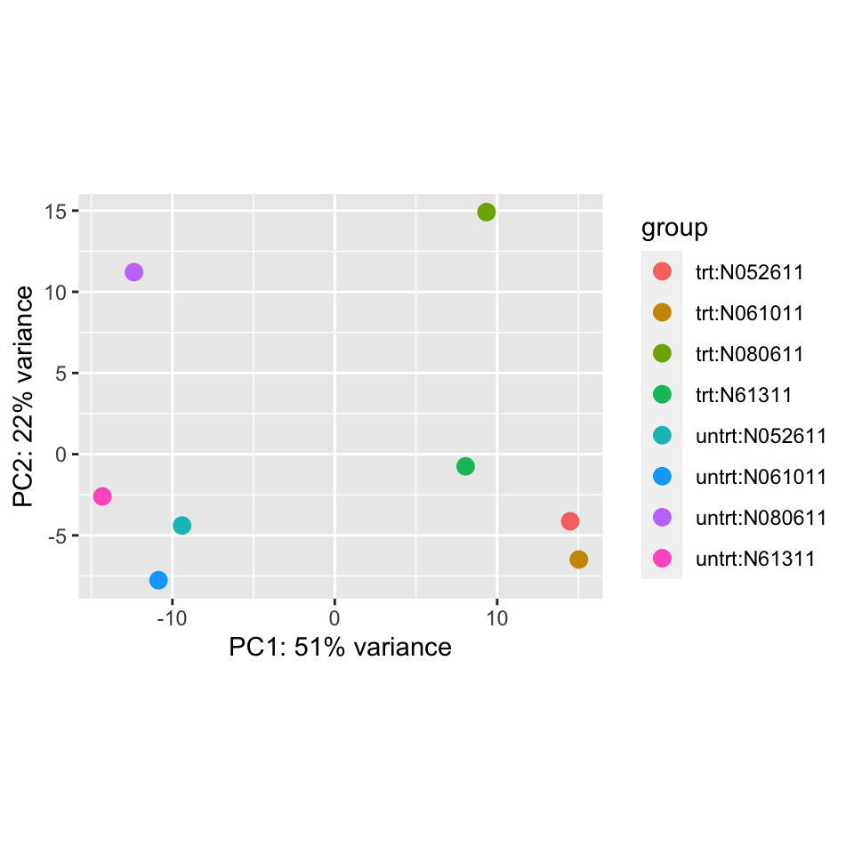

```r
 plotPCA(vsd, intgroup = c("dex", "cell"))
```

```r
# PCA Plot using the VST data. Each unique combination of the treatment and cell line is given its own color

# intgroup are interesting groups for labeling the sample: they tell the function to use them to choose color
```

```r
pcaData <- plotPCA(vsd, intgroup = c( "dex", "cell"), returnData = TRUE)
pcaData
```

```
##                   PC1        PC2         group   dex    cell       name
## SRR1039508 -14.311369 -2.6000421  untrt:N61311 untrt  N61311 SRR1039508
## SRR1039509   8.058574 -0.7500532    trt:N61311   trt  N61311 SRR1039509
## SRR1039512  -9.404122 -4.3920761 untrt:N052611 untrt N052611 SRR1039512
## SRR1039513  14.497842 -4.1323833   trt:N052611   trt N052611 SRR1039513
## SRR1039516 -12.365055 11.2109581 untrt:N080611 untrt N080611 SRR1039516
## SRR1039517   9.343946 14.9115160   trt:N080611   trt N080611 SRR1039517
## SRR1039520 -10.852633 -7.7618618 untrt:N061011 untrt N061011 SRR1039520
## SRR1039521  15.032816 -6.4860576   trt:N061011   trt N061011 SRR1039521
```

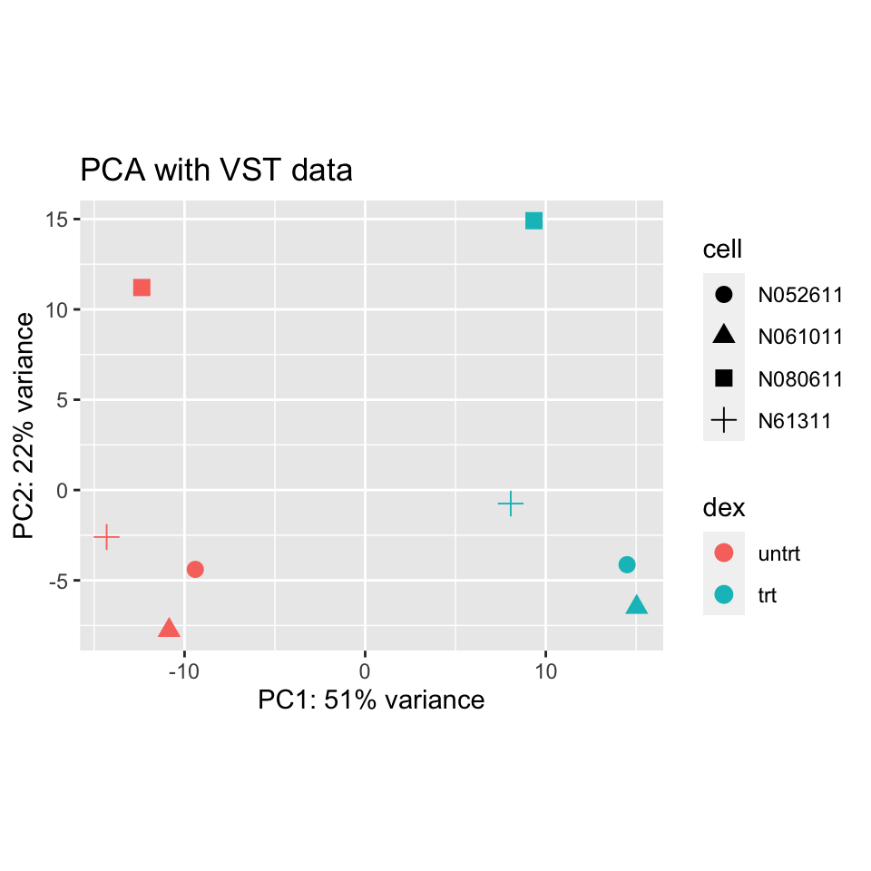

```r
percentVar <- round(100 * attr(pcaData, "percentVar"))

# use this data to build a second plot in a figure, specifying the color of the points should reflect dexamethasone treatment and shape should reflect cell line

ggplot(pcaData, aes(x = PC1, y = PC2, color = dex, shape = cell)) +
  geom_point(size =3) +
  xlab(paste0("PC1: ", percentVar[1], "% variance")) +
  ylab(paste0("PC2: ", percentVar[2], "% variance")) +
  coord_fixed() +
  ggtitle("PCA with VST data")
```

```r
# PCA plot using the VST values with custom ggplot2 code. Here we specify cell line (plotting symbol) and dexamethasone treatment (color).

# in the PCA plot, see differences between cells (different plotting shapes) are considerable, though not stronger than the differences due to treatment with dexamethasone (red vs blue color); shows why it is important to account for this in differential testing by using a paired design (this was set up by assigning formula ~ cell + dex)

## 4.5 PCA plot using Generalized PCA
# generalized principal component analysis (GLM-PCA) allows for dimension reduction on data that is not normally distributed by taking input as the count matrix, as well as the number of latent dimensions to fit
```

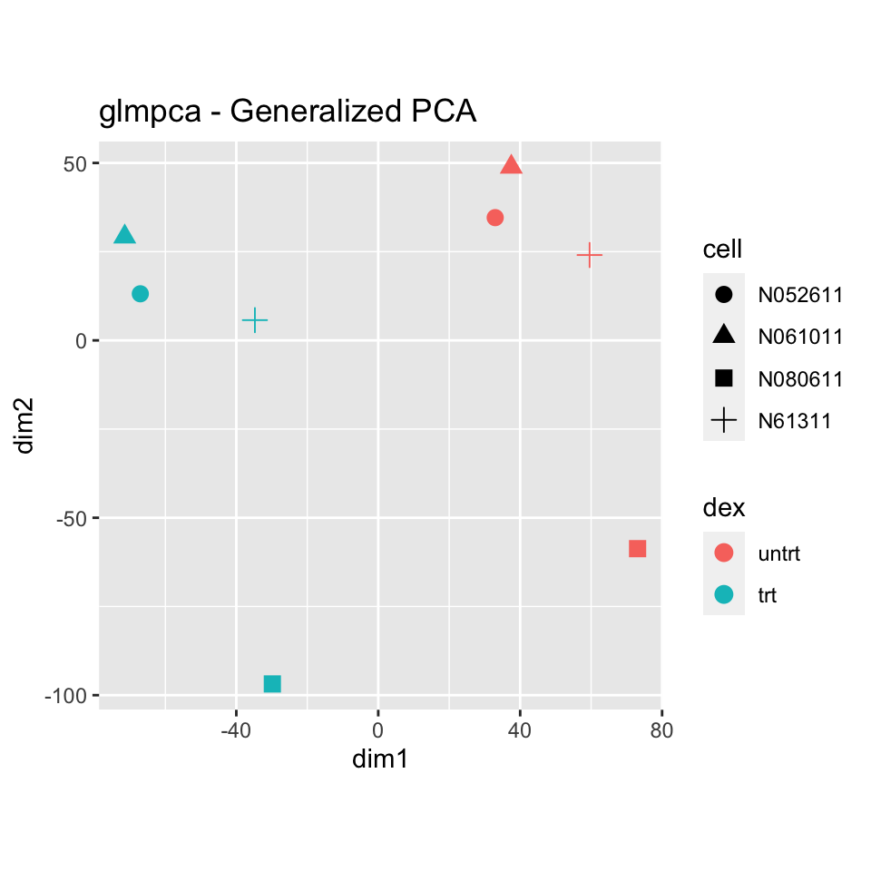

```r
# GLM-PCA operates on raw counts
library("glmpca")
gpca <- glmpca(counts(dds), L=2)
gpca.dat <- gpca$factors
gpca.dat$dex <- dds$dex
gpca.dat$cell <- dds$cell

ggplot(gpca.dat, aes(x = dim1, y = dim2, color = dex, shape = cell)) +
  geom_point(size =3) + coord_fixed() + ggtitle("glmpca - Generalized PCA")
```

## 4.6 MDS Plot

```r
# multidimensional scaling (MDS) function is useful when there is not a matrix of data, but only a matrix of distances
```

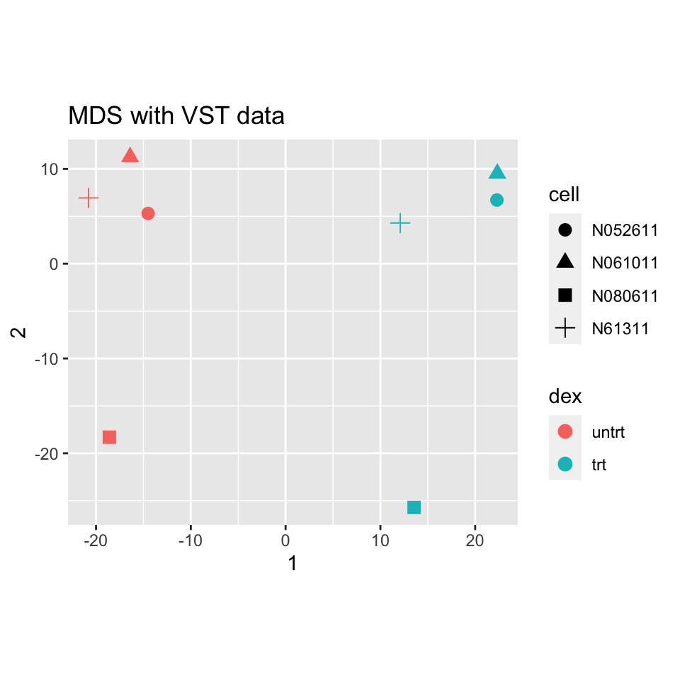

```r
# compute MDS for the distances calculated from the VST data and plot these in figure below
mds <- as.data.frame(colData(vsd))  %>%
         cbind(cmdscale(sampleDistMatrix))
ggplot(mds, aes(x = `1`, y = `2`, color = dex, shape = cell)) +
  geom_point(size = 3) + coord_fixed() + ggtitle("MDS with VST data")
```

```r
# MDS plot using VST data`
```

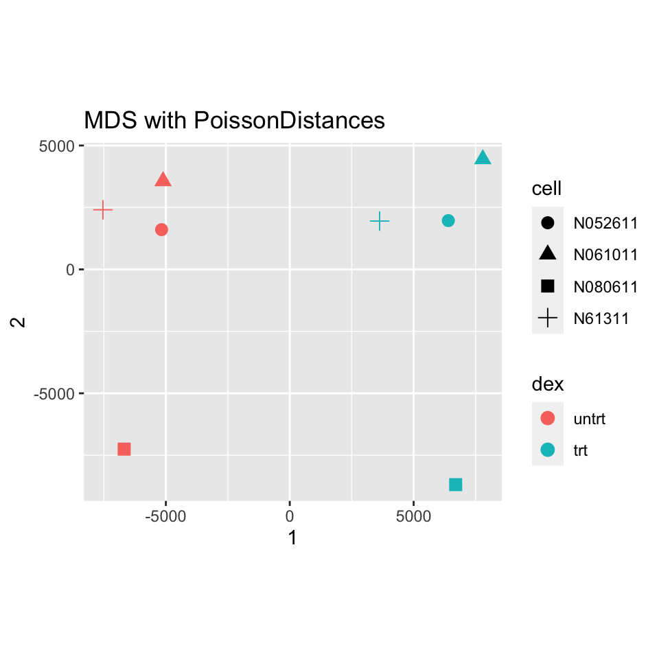

```r
# shows the same plot for the PoissonDistance
mdsPois <- as.data.frame(colData(dds)) %>%
   cbind(cmdscale(samplePoisDistMatrix))
ggplot(mdsPois, aes(x = `1`, y = `2`, color = dex, shape = cell)) +
  geom_point(size = 3) + coord_fixed() + ggtitle("MDS with PoissonDistances")
```

```r
# MDS plotusing Poisson Distance
```

## 5. Differential Expression Analysis

# 5.1 Running differential expression pipeline

```r
# use DESequ to run the differential expression pipeline on the raw counts with a single call

dds <- DESeq(dds)
```

```r
# DESeq allow for estimation of size factors (controlling for differences in sequencing depth of the samples), the estimation of dispersion values for each gene, and fitting a generalized linear model
```

## 5.2 Building the result table

```r
# calling results without any arugments will extract the log2 estimated log2 fold changes and p values for the last variable in the design formula (if there are more than 2 levels for this variable, results will extract the results table for a comparison of the last level over the first level), and comparison is printed at top of the output
```

```r
res <- results(dds)
res
```

```
## log2 fold change (MLE): dex trt vs untrt
## Wald test p-value: dex trt vs untrt
## DataFrame with 31604 rows and 6 columns
##                      baseMean log2FoldChange     lfcSE      stat      pvalue
##                     <numeric>      <numeric> <numeric> <numeric>   <numeric>
## ENSG00000000003.14 739.940717     -0.3611537  0.106869 -3.379419 0.000726392
## ENSG00000000419.12 511.735722      0.2063147  0.128665  1.603509 0.108822318
## ENSG00000000457.13 314.194855      0.0378308  0.158633  0.238479 0.811509461
## ENSG00000000460.16  79.793622     -0.1152590  0.314991 -0.365912 0.714430444
## ENSG00000000938.12   0.307267     -1.3691185  3.503764 -0.390757 0.695977205
## ...                       ...            ...       ...       ...         ...
## ENSG00000285979.1   38.353886      0.3423657  0.359511  0.952310    0.340940
## ENSG00000285987.1    1.562508      0.7064145  1.547295  0.456548    0.647996
## ENSG00000285990.1    0.642315      0.3647333  3.433276  0.106235    0.915396
## ENSG00000285991.1   11.276284     -0.1165515  0.748601 -0.155692    0.876275
## ENSG00000285994.1    3.651041     -0.0960094  1.068660 -0.089841    0.928414
##                          padj
##                     <numeric>
## ENSG00000000003.14 0.00531137
## ENSG00000000419.12 0.29318870
## ENSG00000000457.13 0.92255697
## ENSG00000000460.16 0.87298038
## ENSG00000000938.12         NA
## ...                       ...
## ENSG00000285979.1    0.600750
## ENSG00000285987.1          NA
## ENSG00000285990.1          NA
## ENSG00000285991.1    0.952921
## ENSG00000285994.1          NA
```

```r
# can equivalently produce results table with more specific command: since dex is last variable, can leave off contrast argument to extract the comparison of two levels of dex

res <- results(dds, contrast=c("dex","trt","untrt"))

# as res is a dataframe object, it carries metadata with info on the meaning of the columns

mcols(res, use.names = TRUE)
```

```
## DataFrame with 6 rows and 2 columns
##                        type                               description
##                 <character>                               <character>
## baseMean       intermediate mean of normalized counts for all samples
## log2FoldChange      results  log2 fold change (MLE): dex trt vs untrt
## lfcSE               results          standard error: dex trt vs untrt
## stat                results          Wald statistic: dex trt vs untrt
## pvalue              results       Wald test p-value: dex trt vs untrt
## padj                results                      BH adjusted p-values
```

```r
# the first column, baseMean, is the average of the normalized count values, divided by size factors, taken over all samples in the DESeqDataSet

# remaining four columns refer to a specific contrast, namely the comparison of the trt level over the untrt level for the factor variable dex

# column log2fold is the effect size estimate: tells us how much the gene's expression seems to be have changed due to treatment with dexamethasone in comparison to untreated samples (value is reported on a log scale to base 2; for ex., a log2 fold change of 1.5 means that the gene's expression is increase by a multiplicative factor of 2^1.5 = ~ 2.82)

# estimate has an uncertainty associated with it, which is available in the column lfcSE, the standard error estimate for the log2 fold change estimate; can express uncertainty of a particular effect size estimate as the result of a statistical test; purpose of this test for differential expression is to test whether the data provides sufficient evidence to conclude that this value is really different from zero

# DESeq2 performs for each gene a hypothesis test to see whether evidence is sufficient to decide against null hypothesis that there is zero effect of the treatment on the gene and that the observed difference between treatment and control was merely caused by experimental variability (i.e., the type of variability that you can expect between different samples in the same treatment group)

# the result of the DESeq2 test is reported as a p value, and it is found in the column pvalue (indicates probability that a fold change as strong as the observed one, or even stronge,r would be seen under the situation described the null hypothesis)
```

```r
# summarize the results
summary(res)
```

```
##
## out of 31604 with nonzero total read count
## adjusted p-value < 0.1
## LFC > 0 (up)       : 2373, 7.5%
## LFC < 0 (down)     : 1949, 6.2%
## outliers [1]       : 0, 0%
## low counts [2]     : 14706, 47%
## (mean count < 9)
## [1] see 'cooksCutoff' argument of ?results
## [2] see 'independentFiltering' argument of ?results
```

```r
# to be more strict about which set of genes are significant:
## lower the false discovery rate threshold (the threshold on padj in the results table)
## raise the log2 fold change threshold form 0 using the lfcThreshold argument of results
```

```r
# lowering the false discovery rate threshold, inform the results about it so that the function can use the threshold for the optimal independent filtering

res.05 <- results(dds, alpha = 0.05)
table(res.05$padj < 0.05)
```

```
##
## FALSE  TRUE
## 13357  3541
```

```r
# to raise log2 fold change threshold, test for genes that show more substantial changes due to treatment, supply a value on the log2 scale; specifying lfcThreshold = 1, we test for genes that show signficant effects of treatment on gene counts more than doubling or less than halving since 2^1 = 2

resLFC1 <- results(dds, lfcThreshold=1)
table(resLFC1$padj < 0.1)
```

```
##
## FALSE  TRUE
## 16687   211
```

```r
# sometimes, a subset of p-values in res will be NA; this is DESeq's way of reporting that all counts for this gene was zero, and hence no test was applied; p values can be assigned NA if the gene was excluded from analysis because it contained an extreme count outlier

## CITING PACKAGES
# if you use result from an R analysis package, you can find the proper citation for the software by typing citation("pkgName"), where you would substitute the name of the package for pkgName : citing methods papers helps to support and reward the indiviudals who put time into open source software for genomic data analysis
```

## 5.3 Other Comparisons

```r
# the results for a comparison of any two levels of a variable can be extracted using the contrast argument to results; the user should specify three values: name of the variable, name of the level for the numerator, and name of the level for the denominator

results(dds, contrast = c("cell", "N061011", "N61311"))
```

```
## log2 fold change (MLE): cell N061011 vs N61311
## Wald test p-value: cell N061011 vs N61311
## DataFrame with 31604 rows and 6 columns
##                      baseMean log2FoldChange     lfcSE       stat    pvalue
##                     <numeric>      <numeric> <numeric>  <numeric> <numeric>
## ENSG00000000003.14 739.940717       0.270945  0.152171   1.780534 0.0749886
## ENSG00000000419.12 511.735722      -0.071831  0.182817  -0.392912 0.6943842
## ENSG00000000457.13 314.194855       0.179881  0.225122   0.799036 0.4242696
## ENSG00000000460.16  79.793622      -0.119482  0.441594  -0.270570 0.7867217
## ENSG00000000938.12   0.307267       0.000000  4.997580   0.000000 1.0000000
## ...                       ...            ...       ...        ...       ...
## ENSG00000285979.1   38.353886      0.0589757  0.512391  0.1150989  0.908367
## ENSG00000285987.1    1.562508      1.0216804  2.201861  0.4640078  0.642642
## ENSG00000285990.1    0.642315     -3.0956404  4.852715 -0.6379193  0.523526
## ENSG00000285991.1   11.276284     -0.8779628  1.046963 -0.8385804  0.401705
## ENSG00000285994.1    3.651041     -0.0192351  1.513236 -0.0127112  0.989858
##                         padj
##                    <numeric>
## ENSG00000000003.14  0.378828
## ENSG00000000419.12  0.936703
## ENSG00000000457.13  0.820733
## ENSG00000000460.16  0.960662
## ENSG00000000938.12        NA
## ...                      ...
## ENSG00000285979.1    0.98371
## ENSG00000285987.1         NA
## ENSG00000285990.1         NA
## ENSG00000285991.1         NA
## ENSG00000285994.1         NA
```

```r
# there are additional ways to build results for certain comparisons after running DESeq once; if results for an interaction term are desired, the name argument of results should be used
```

## 5.4 Multiple testing

```r
# in biology, careful to not use p values directly as evidence against the null, but to correct for multiple testing
```

```r
sum(res$pvalue < 0.05, na.rm = TRUE)
```

```
## [1] 5170
```

```r
sum(!is.na(res$pvalue))
```

```
## [1] 31604
```

```r
# assume null hypothesis is true for all genes (no gene is affected by dexamethasone); then, by definition of the p value, we expect up to 5% of the genes to have a p value below a 0.05 -> this will lead to a total of 1580 genes; if we then considered the list of genes with a p value below 0.05 as differentially expressed, this list should be expect to contain up tp 1580 / 5170 = 31% false positives

# DESeq2 uses Benjamini-Hochberg adjustment, which calculates for each gene an adjusted p value that answers the followin question: if one called significant all genes with an adjusted p value less than or equal to this gene's adjusted p value threshold, what would be the fraction of false positives (the false discovery rate, FDR) among them, in the sense of the calculation outlined above? These values, called BH-adjusted p values, are given in the column padj of the res object

# FDR is a useful statistic for many high-throughput experiments, as we are often interested in reporting or focusing on a set of interesting genes, and we would like to put an upper bound on the percent of false positives in this set
```

```r
# consider a fraction of 10% of false positives acceptable, we can consider all genes with an adjusted o value below 10% = 0.1 as significant. how many genes is that?

sum(res$padj < 0.1, na.rm = TRUE)
```

```
## [1] 4322
```

```r
# sort it by log2 fold change estimate to get the significant genes with strongest down-regulation

resSig <- subset(res, padj < 0.1)
head(resSig[ order(resSig$log2FoldChange), ])
```

```
## log2 fold change (MLE): dex trt vs untrt
## Wald test p-value: dex trt vs untrt
## DataFrame with 6 rows and 6 columns
##                    baseMean log2FoldChange     lfcSE      stat      pvalue
##                   <numeric>      <numeric> <numeric> <numeric>   <numeric>
## ENSG00000216490.3   42.3007       -5.72483  1.475652  -3.87952 1.04661e-04
## ENSG00000267339.5   30.5206       -5.39781  0.773017  -6.98278 2.89390e-12
## ENSG00000257542.5   10.0399       -5.25991  1.282001  -4.10289 4.08015e-05
## ENSG00000146006.7   61.6448       -4.49504  0.663821  -6.77147 1.27484e-11
## ENSG00000108700.4   14.6324       -4.09069  0.941842  -4.34328 1.40369e-05
## ENSG00000213240.8   12.0962       -3.87313  1.274133  -3.03981 2.36725e-03
##                          padj
##                     <numeric>
## ENSG00000216490.3 9.87853e-04
## ENSG00000267339.5 9.45863e-11
## ENSG00000257542.5 4.30646e-04
## ENSG00000146006.7 3.82632e-10
## ENSG00000108700.4 1.66687e-04
## ENSG00000213240.8 1.44987e-02
```

```r
# strongest up-regulation
head(resSig[ order(resSig$log2FoldChange, decreasing = TRUE), ])
```

```
## log2 fold change (MLE): dex trt vs untrt
## Wald test p-value: dex trt vs untrt
## DataFrame with 6 rows and 6 columns
##                     baseMean log2FoldChange     lfcSE      stat      pvalue
##                    <numeric>      <numeric> <numeric> <numeric>   <numeric>
## ENSG00000254692.1    62.2302       10.20714   3.37706   3.02250 2.50700e-03
## ENSG00000179593.15   67.0895        9.50515   1.07705   8.82513 1.09334e-18
## ENSG00000268173.3    46.4370        8.40438   3.38506   2.48279 1.30358e-02
## ENSG00000224712.12   35.5607        7.16686   2.16476   3.31070 9.30628e-04
## ENSG00000109906.13  438.1940        6.37750   0.31381  20.32276 8.08934e-92
## ENSG00000257663.1    24.3946        6.34758   2.09531   3.02942 2.45024e-03
##                           padj
##                      <numeric>
## ENSG00000254692.1  1.52167e-02
## ENSG00000179593.15 6.81746e-17
## ENSG00000268173.3  5.94385e-02
## ENSG00000224712.12 6.55240e-03
## ENSG00000109906.13 1.24267e-88
## ENSG00000257663.1  1.49151e-02
```

## 6. Counts Plot

```r
# to visualize counts for a particular gene, use plotCounts that takes as arguments the DESeqDataSet, a gene name, and the group over which to plot the counts
```

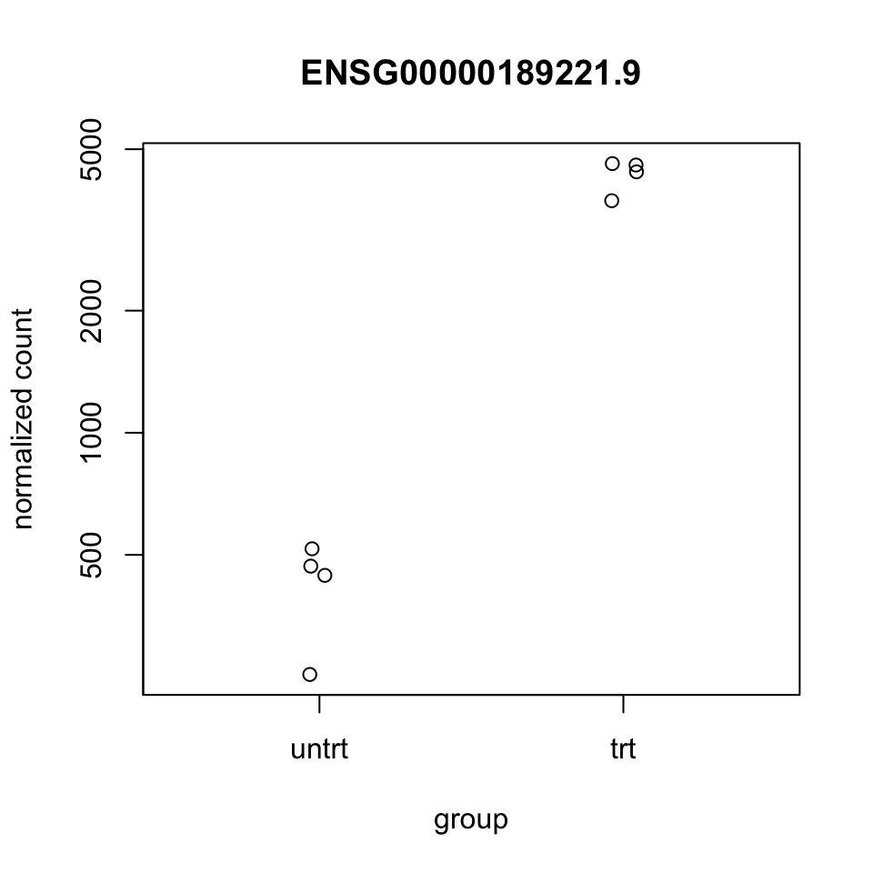

```r
topGene <- rownames(res)[which.min(res$padj)]
plotCounts(dds, gene = topGene, intgroup=c("dex"))
```

```r
# Normalize counts for a single gene over treatment group
```

# customized plots

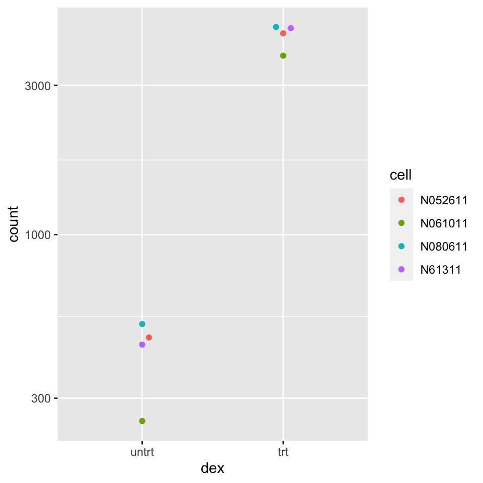

```r
library("ggbeeswarm")
geneCounts <- plotCounts(dds, gene = topGene, intgroup = c("dex","cell"),
                         returnData = TRUE)
ggplot(geneCounts, aes(x = dex, y = count, color = cell)) +
  scale_y_log10() +  geom_beeswarm(cex = 3)
```

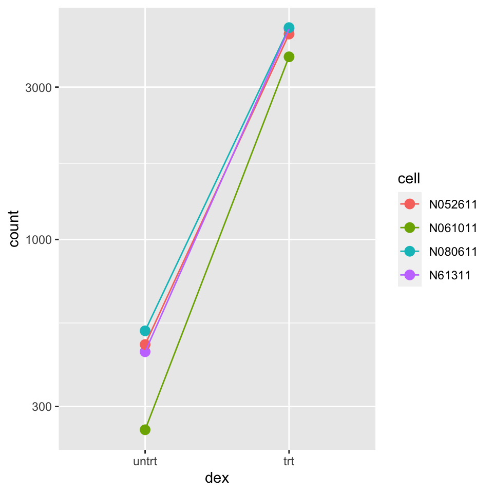

```r
ggplot(geneCounts, aes(x = dex, y = count, color = cell, group = cell)) +
  scale_y_log10() + geom_point(size = 3) + geom_line()
```

```r
# Normalized counts with lines connecting cell lines
```